Þetta er þriðja verkefnið í áfanganum líkindafræði og tölfræði. Notuð verða göng Hafrannsóknarstofnunnar frá árinu 1998 með ýmsum mælingum á fiskum eftir hafsvæði í “togararalli” stofnunarinnar það árið. Mismunandi liðir verkefnisins eru útlistaðir hér að neðan í mismunandi “tabs” athugið að R kóði er falinn og hægt að kalla fram með því að smella á “Code” takka.  
Eftirfarandi pakkar verða notaðir í þessu verkefni

```r
library(tidyverse)
library(knitr)
```

## a

### Gögn og gagnahreinsun

Sækjum gögnin **data98.csv** af notendasvæði Gunnars:

```r
sr <- read.csv("http://hi.is/~gunnar/LikTol/data98.csv")

#Eru einhverjir dálkar í vitlausum klassa
str(sr)
```

```
## 'data.frame':    3681 obs. of  17 variables:
##  $ recid  : int  100000 100000 100000 100000 100000 100000 100000 100000 100000 100000 ...
##  $ reit   : int  475 475 475 475 475 475 475 475 475 475 ...
##  $ smrt   : int  4 4 4 4 4 4 4 4 4 4 ...
##  $ tog_nr : int  13 13 13 13 13 13 13 13 13 13 ...
##  $ dag    : int  7 7 7 7 7 7 7 7 7 7 ...
##  $ man    : int  3 3 3 3 3 3 3 3 3 3 ...
##  $ dyp_min: int  201 201 201 201 201 201 201 201 201 201 ...
##  $ dyp_max: int  202 202 202 202 202 202 202 202 202 202 ...
##  $ vf     : int  73 73 73 73 73 73 73 73 73 73 ...
##  $ nr     : int  1 11 12 13 14 15 16 17 18 19 ...
##  $ le     : int  56 42 42 42 49 64 62 57 63 47 ...
##  $ ky     : int  2 1 1 2 1 1 1 1 2 2 ...
##  $ kt     : int  1 1 1 1 1 2 1 1 1 1 ...
##  $ aldur  : int  4 3 3 3 3 5 5 5 5 3 ...
##  $ osl    : int  1383 633 513 701 910 2153 1568 1713 1874 870 ...
##  $ sl     : int  1294 582 488 643 842 1748 1519 1469 1629 814 ...
##  $ li     : num  25 12 7 22 16 110 38 38 145 19 ...
```

Gagnasettið er í lagi.

Næst þurfum við að skilgreina fjögur mismunandi hafsvæði út frá legu tilkynningaskyldureita eftir lengdar og breiddar baugum. Númer tilkynningaskyldu reitanna er gefið upp sem “statistcial rectangle code” sem hægt er að breyta yfir í tvívíð hnit með fallinu `r2d` sem gefið er í verkefnalýsingunni.

```r
#r2d er fall sem gefið er í verkefnalýsingunni og er ætlað til að breyta tilkynningaksyldureitanýmerum í tvívíð hnit.
r2d <-function(r)
{
    lat <- floor(r/100)
    lon <- (r - lat * 100) %% 50
    halfb <- (r - 100 * lat - lon)/100
    lon <-  - (lon + 0.5)
    lat <- lat + 60 + halfb + 0.25
    data.frame(lat = lat, lon = lon)
}

#Bæti næst við breytum um hafsvæði út frá lengdar og breiddarbaugum auk upplýsingar um kynþroska fiskanna
sr <- bind_cols(sr,r2d(sr$reit)) %>%
  mutate(hafsvaedi=as.factor(
    paste(
      ifelse(lat<65,"S","N"), #Breiddarbaugur (latitude) < 65 er suður
      ifelse(lon>-19,"A","V"), #Lengdarbaugur (longitude) > 19 er austur
      sep=""
      )
    ),
    kt2 = as.factor(ifelse(kt==1,"Ókynþroska","Kynþroska"))
  )
```

## b

### Kynþroski fiska

Búum til töflu sem sýnir þroskastig fiska eftir mismunandi hafsvæðum. Sameina tíðnitölur og prósentur:

```r
group_by(sr,hafsvaedi) %>%
  summarise(kyn = paste(sum(kt2=="Kynþroska")," (",round(100*sum(kt2=="Kynþroska")/n()),"%)",sep=""),
            okyn = paste(sum(kt2=="Ókynþroska")," (",round(100*sum(kt2=="Ókynþroska")/n()),"%)",sep="")) %>%
  kable(col.names = c("Hafsvæði","Kynþroska","Ókynþroska"), align = "c")
```

| Hafsvæði | Kynþroska | Ókynþroska |
| --- | --- | --- |
| NA | 215 (18%) | 981 (82%) |
| NV | 394 (30%) | 934 (70%) |
| SA | 224 (52%) | 204 (48%) |
| SV | 508 (70%) | 221 (30%) |

Við sjáum á gögnunum að það er ákveðið trend í átt til þess að hærra hlutfall fiskana sé kynþroska á Suður og vesturlægum hafsvæðum. Við höfum þó ekki gert viðeigandi tilgátupróf til að fullyrða nokkuð um slík tengsl.

#### Myndræn framsetning

Næst gerum við stöplarit sem sýnir tíðni kynþroska fiskanna eftir hafsvæði.

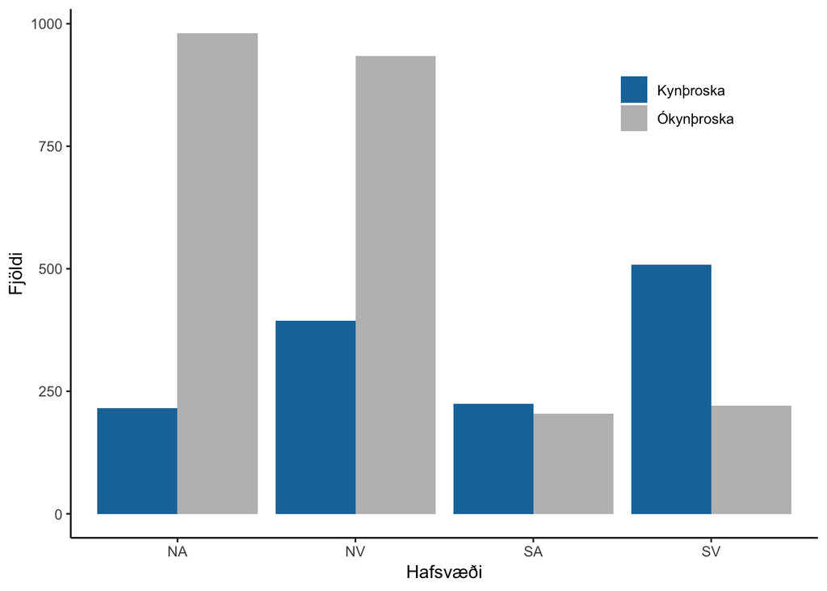

```r
ggplot(sr,aes(x=hafsvaedi,fill=kt2)) +
  geom_bar(position = "dodge") +
  labs(x="Hafsvæði",y="Fjöldi",fill="")+
  scale_fill_manual(values = c( "#1676A9","gray")) +
  theme_classic()+
  theme(legend.justification=c(1,0),
        legend.position=c(0.90, 0.75),
        legend.background = element_blank(),
        legend.key = element_blank())
```

## c

### Þyngd og lengd fiska

Gerum töflu sem sýnir meðallengd og meðalþyngd og staðalfrávik eftir aldri fiskana. Í þessu tilviki skoðum við óslægða þyngd fiskana (lifandi vigt).

```r
#Geymum þessa töflu svo við getum kallað upp meðaltölin seinna í myndrænu framsetningunni
group_by(sr,aldur) %>%
  summarise(lengd = paste(round(mean(le))," (",round(sd(le),digits=2),")",sep=""),
            thyngd = paste(round(mean(osl))," (",round(sd(osl)),")",sep="")
            ) %>%
  kable(col.names = c("Aldur","Meðallengd (staðalfrávik)","Meðalþyngd (staðalfrávik)"),align = "c")
```

| Aldur | Meðallengd (staðalfrávik) | Meðalþyngd (staðalfrávik) |
| --- | --- | --- |
| 1 | 23 (2.08) | 102 (41) |
| 2 | 26 (3.72) | 166 (92) |
| 3 | 39 (5.28) | 529 (245) |
| 4 | 51 (7.9) | 1339 (1213) |
| 5 | 61 (6.82) | 2133 (935) |
| 6 | 71 (8.7) | 3425 (1508) |
| 7 | 79 (8.88) | 4767 (2011) |
| 8 | 85 (9.99) | 6407 (2978) |
| 9 | 89 (9.82) | 7266 (2987) |
| 10 | 94 (12.88) | 9393 (5882) |
| 11 | 94 (24.31) | 10665 (7293) |
| 13 | 132 (NA) | 28282 (NA) |
| 14 | 145 (NA) | 34484 (NA) |
| 15 | 110 (NA) | 12750 (NA) |

#### Myndræn framsetning

Teiknum tvær myndir.

##### Fyrsta mynd

Mynd eitt sýnir lengd fiska eftir aldri sem samfelld breyta. Einnig verða sér merkt meðaltöl fyrir hvern aldur sem rauður punktur.

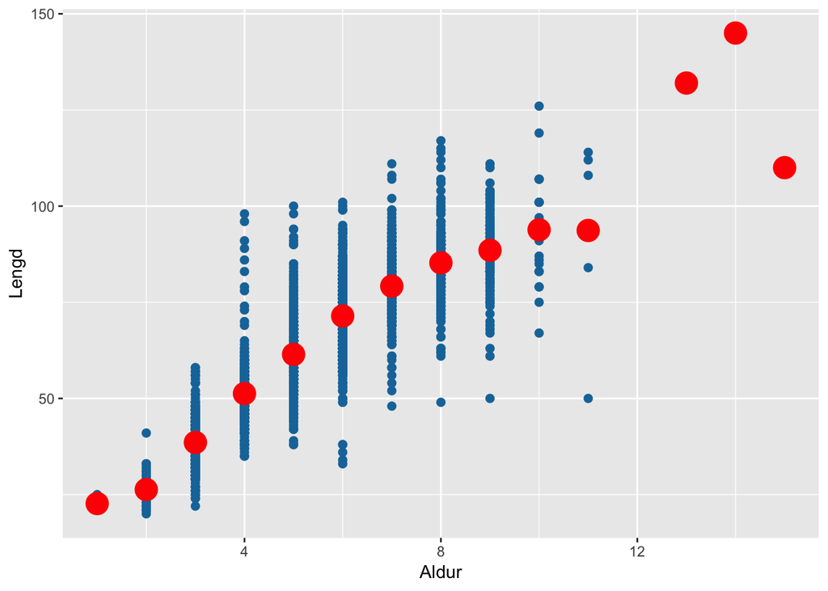

```r
#Búum til nýtt gagnasett þar sem við bætum við röðum sem innihalda meðallengd. Þær línur getum við svo notað til að gera stærri rauða punkta fyrir meðalþyngd eftir aldri.
tmp_dat <- bind_rows(mutate(sr,med=F),
                     group_by(sr,aldur) %>% summarise(le=mean(le),med=T)) %>%
  select(aldur,le,med)

#Notum med breytuna til að tilgreina þá punkta sem eru meðaltöl
ggplot(tmp_dat,aes(x=aldur,y=le,color=med,size=med)) +
  geom_point()+
  labs(x="Aldur",y="Lengd")+
  guides(color=F,size=F)+
  scale_color_manual(values = c("#1676A9","red"))
```

##### Önnur mynd

Mynd tvö sýnir sömu gögn en í staðin er aldur höndlaður eins og strjál breyta. Notum til þess kassarit.

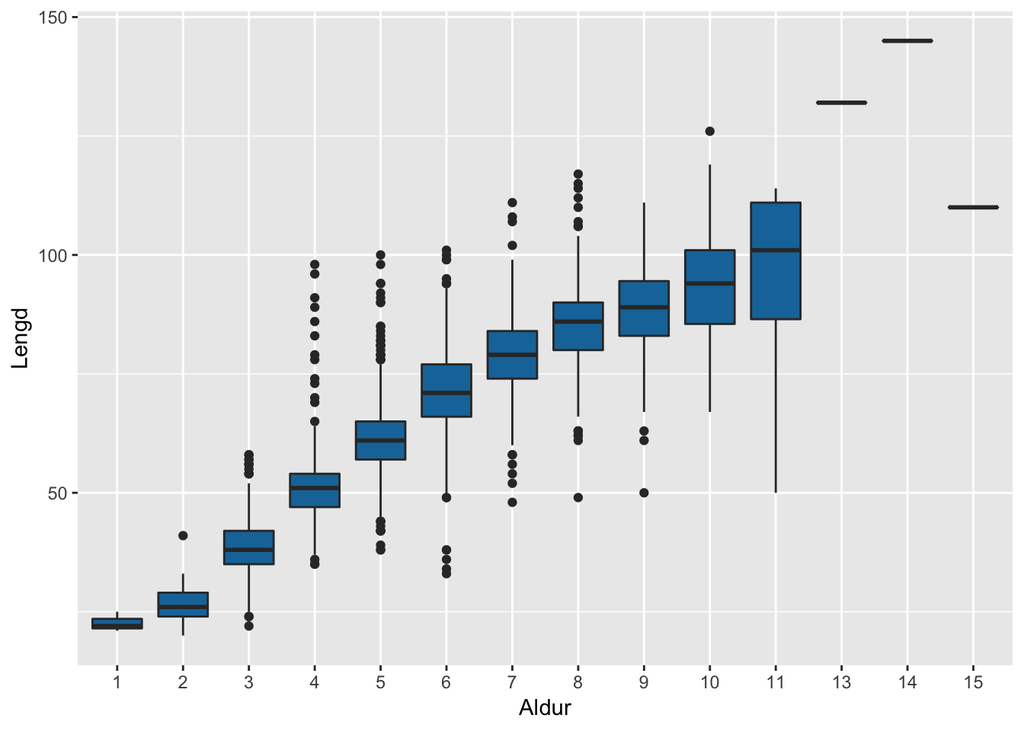

```r
ggplot(sr,aes(x=as.factor(aldur),y=le,fill=!is.na(aldur))) +
  geom_boxplot()+
  labs(x="Aldur",y="Lengd")+
  guides(fill=F)+
  scale_fill_manual(values="#1676A9")
```